# Dimension reduction for genomics

Jeff Leek

## Dependencies

This document depends on the following packages:

```r
  library(devtools)
  library(Biobase)
```

To install these packages you can use the code (or if you are compiling the document, remove the `eval=FALSE` from the chunk.)

```r
install.packages(c("devtools"))
source("http://www.bioconductor.org/biocLite.R")
biocLite(c("Biobase"))
```

## General principles

- Can we find patterns in matrices of data?

## Load some data

We will use this expression set that combines two studies [Transcriptome genetics using second generation sequencing in a Caucasian population.](http://www.ncbi.nlm.nih.gov/pubmed?term=20220756%5Buid%5D) and [Understanding mechanisms underlying human gene expression variation with RNA sequencing.](http://www.ncbi.nlm.nih.gov/pubmed?term=20220758). These studies are different populations but we counted the same genes for both. Then we’ll explore the differences.

```r
con =url("http://bowtie-bio.sourceforge.net/recount/ExpressionSets/montpick_eset.RData")
load(file=con)
close(con)
mp = montpick.eset
pdata=pData(mp)
edata=as.data.frame(exprs(mp))
fdata = fData(mp)
ls()
```

```
## [1] "con"           "edata"         "fdata"         "montpick.eset"
## [5] "mp"            "pdata"         "tropical"
```

## Calculate the singular vectors

Here we calculate the singular vectors:

```r
edata = edata[rowMeans(edata) > 100, ]
edata = log2(edata + 1)
edata_centered = edata - rowMeans(edata)
svd1 = svd(edata_centered)
names(svd1)
```

```
## [1] "d" "u" "v"
```

## Look at the percent variance explained

The percent of variance explained is given by $\frac{d_{ii}^2}{\sum_{j}d_{jj}^2}$

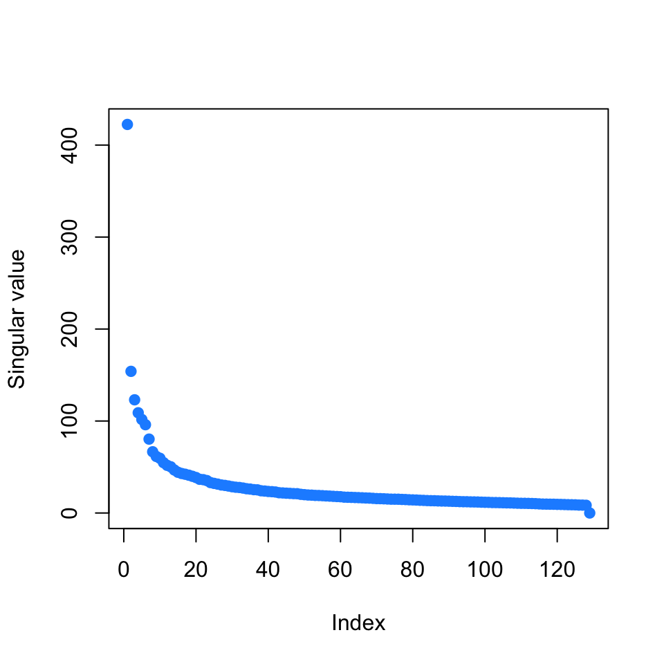

```r
plot(svd1$d,ylab="Singular value",col=2)
```

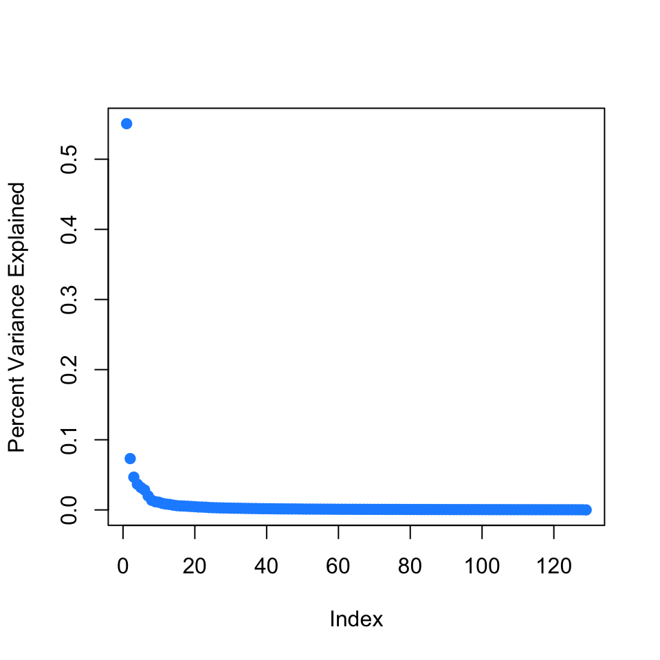

```r
plot(svd1$d^2/sum(svd1$d^2),ylab="Percent Variance Explained",col=2)
```

## Plot top two principal components

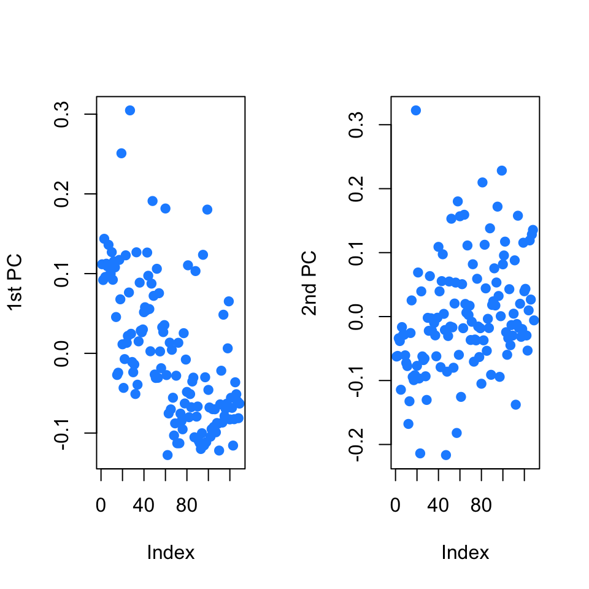

```r
par(mfrow=c(1,2))
plot(svd1$v[,1],col=2,ylab="1st PC")
plot(svd1$v[,2],col=2,ylab="2nd PC")
```

## Plot PC1 vs. PC2

A very common plot is to plot PC1 versus PC2 to see if you can see any “clusters” or “groups”.

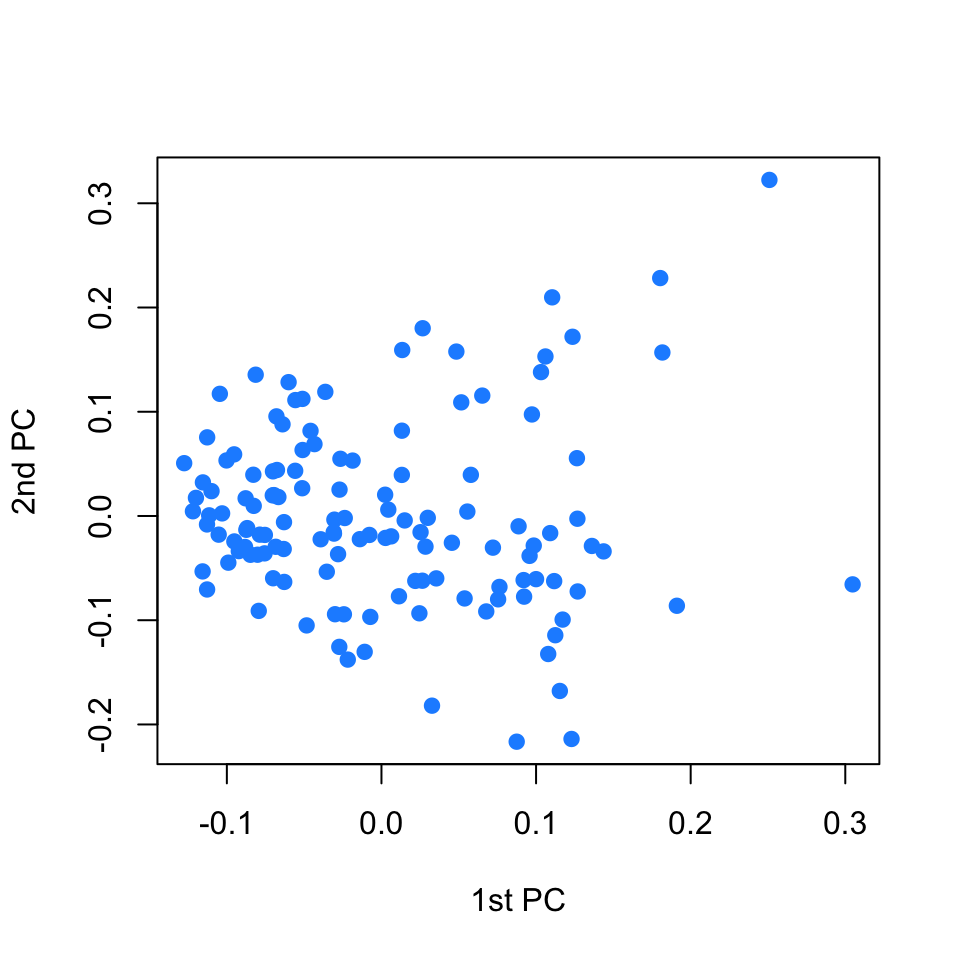

```r
plot(svd1$v[,1],svd1$v[,2],col=2,ylab="2nd PC",xlab="1st PC")
```

One thing you can do is color them by different variables to see if clusters stand out.

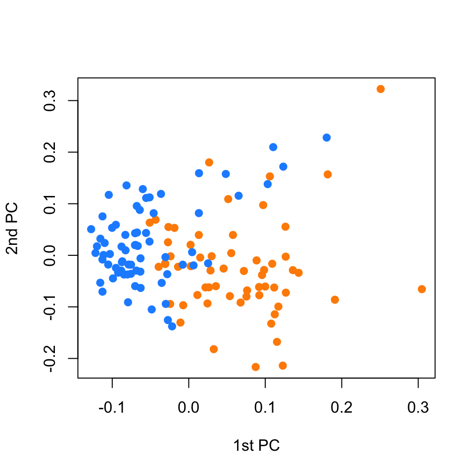

```r
plot(svd1$v[,1],svd1$v[,2],ylab="2nd PC",
     xlab="1st PC",col=as.numeric(pdata$study))
```

Another common plot is to make boxplots comparing the PC for different levels of known covariates (don’t forget to show the actual data!).

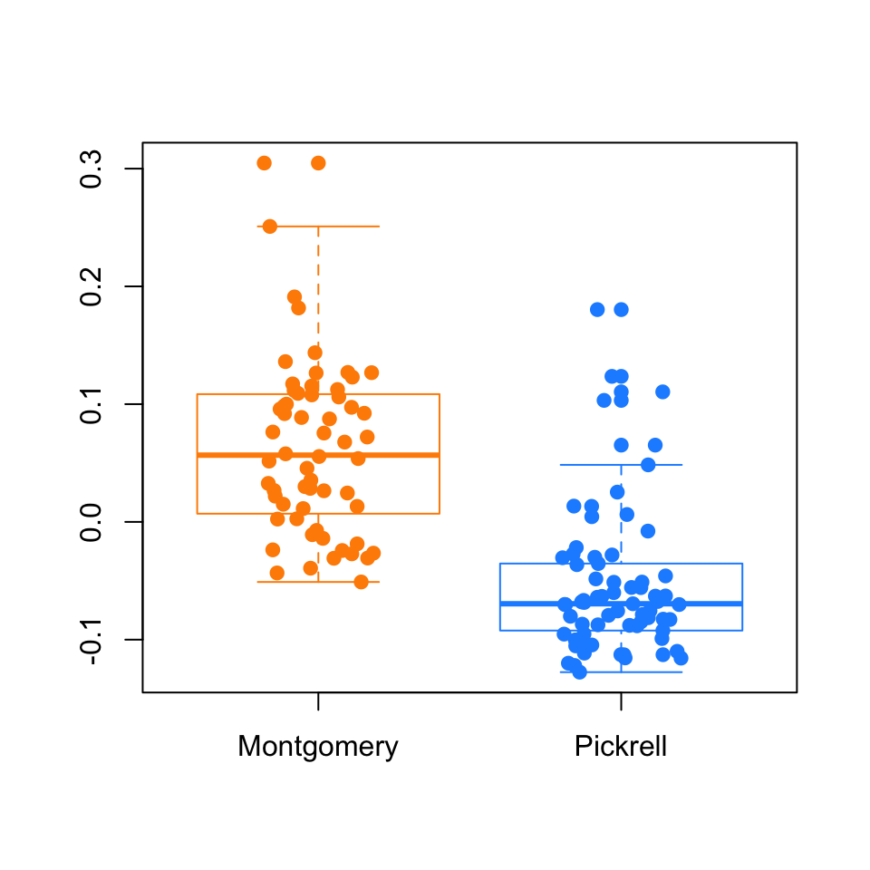

```r
boxplot(svd1$v[,1] ~ pdata$study,border=c(1,2))
points(svd1$v[,1] ~ jitter(as.numeric(pdata$study)),col=as.numeric(pdata$study))
```

## PCs versus SVs

What we have been plotting is not exactly the principal components.

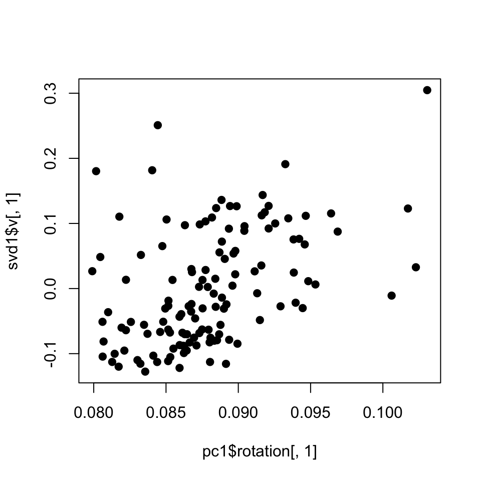

```r
pc1 = prcomp(edata)
plot(pc1$rotation[,1],svd1$v[,1])
```

To get the actual PCs you have to subtract the column means rather than the row means when normalizing.

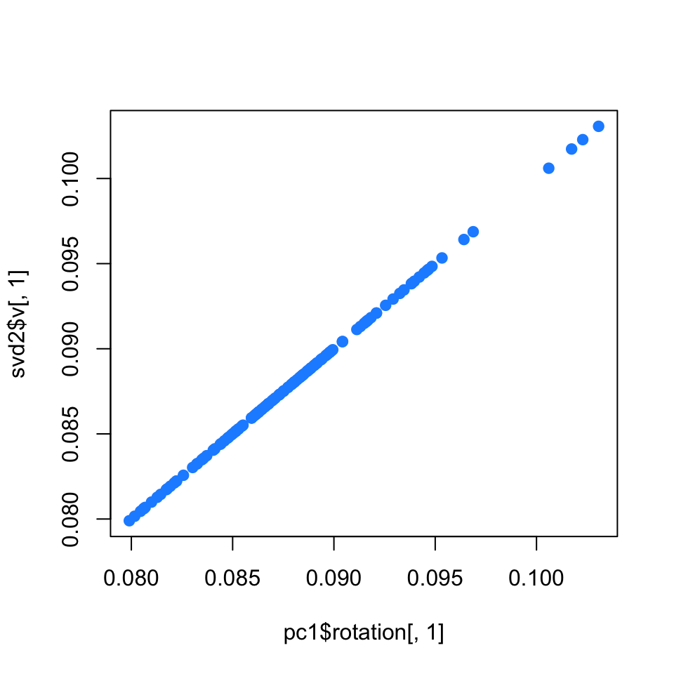

```r
edata_centered2 = t(t(edata) - colMeans(edata))
svd2 = svd(edata_centered2)
plot(pc1$rotation[,1],svd2$v[,1],col=2)
```

Despite this, it is most common for people to perform row-centering and then plot the singular vectors (sometimes labeling them PCs like I have done in this document)

## Outliers

What happens if we introduce a single outlying gene

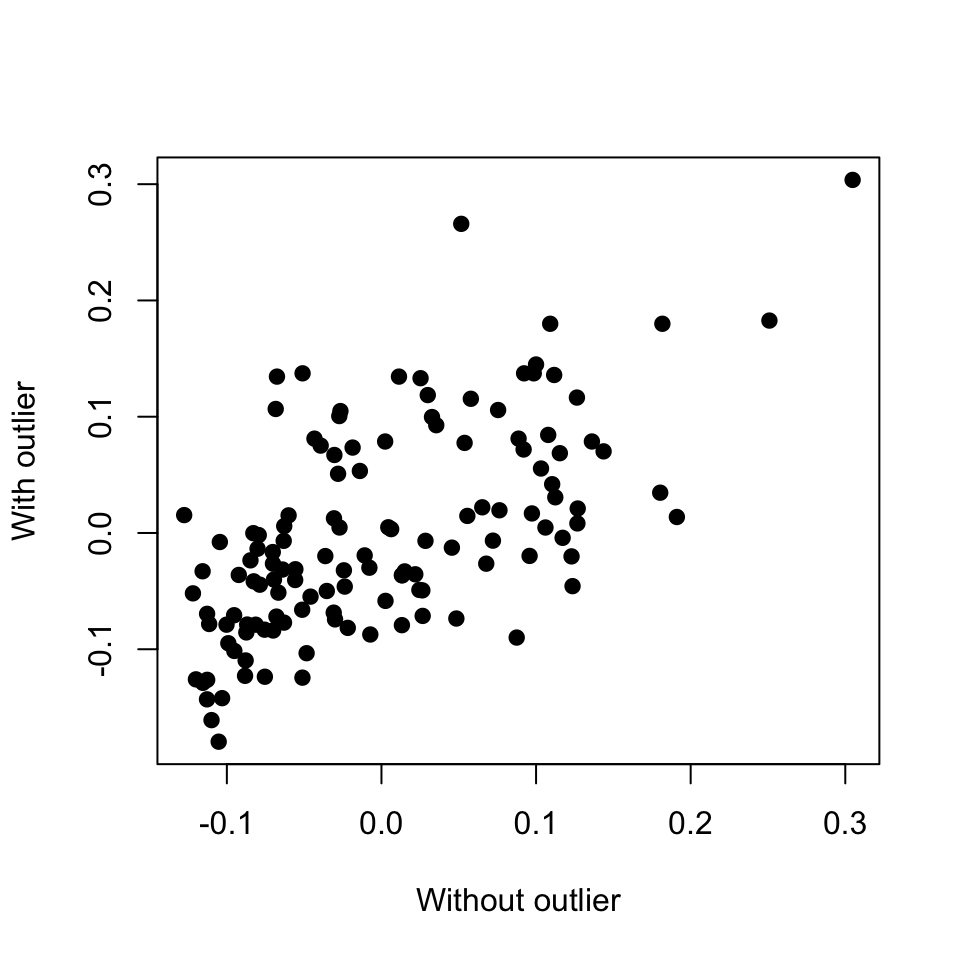

```r
edata_outlier = edata_centered
edata_outlier[6,] = edata_centered[6,] * 10000
svd3 = svd(edata_outlier)
plot(svd1$v[,1],svd3$v[,1],xlab="Without outlier",ylab="With outlier")
```

It turns out the new top singular vector is perfectly correlated with the outlying gene

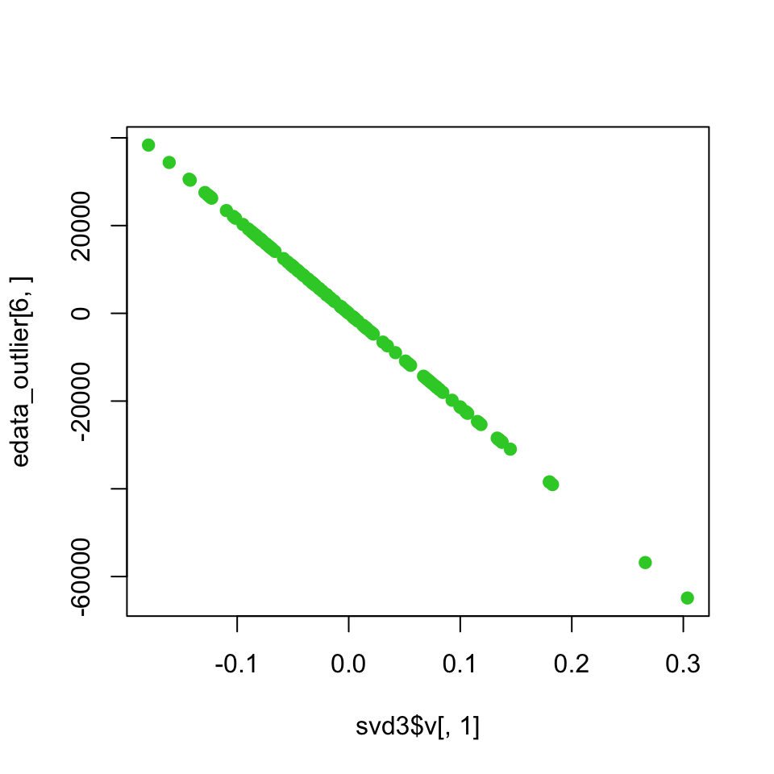

```r
plot(svd3$v[,1],edata_outlier[6,],col=4)
```

## Further resources

There are a large number of resources available about PCA and SVD but the lecture notes from [Advanced Statistics for the Life Sciences](http://genomicsclass.github.io/book/) are the best set of lecture notes focused on genomics currently available.

## Session information

```
##  setting  value
##  version  R version 3.2.2 (2015-08-14)
##  system   x86_64, darwin13.4.0
##  ui       X11
##  language (EN)
##  collate  en_GB.UTF-8
##  tz       Europe/London
##  date     2015-09-19
##
##  package      * version date       source
##  Biobase      * 2.28.0  2015-04-17 Bioconductor
##  BiocGenerics * 0.14.0  2015-04-17 Bioconductor
##  devtools     * 1.9.1   2015-09-11 CRAN (R 3.2.0)
##  digest         0.6.8   2014-12-31 CRAN (R 3.2.0)
##  evaluate       0.8     2015-09-18 CRAN (R 3.2.2)
##  formatR        1.2.1   2015-09-18 CRAN (R 3.2.2)
##  htmltools      0.2.6   2014-09-08 CRAN (R 3.2.0)
##  knitr        * 1.11    2015-08-14 CRAN (R 3.2.2)
##  magrittr       1.5     2014-11-22 CRAN (R 3.2.0)
##  memoise        0.2.1   2014-04-22 CRAN (R 3.2.0)
##  rmarkdown      0.8     2015-08-30 CRAN (R 3.2.2)
##  stringi        0.5-5   2015-06-29 CRAN (R 3.2.0)
##  stringr        1.0.0   2015-04-30 CRAN (R 3.2.0)
##  yaml           2.1.13  2014-06-12 CRAN (R 3.2.0)
```

It is also useful to compile the time the document was processed. This document was processed on: 2015-09-19.